# Using the Loads Regression Estimator (LRE) to quantify loads and uncertainties

Petra Kuhnert, Dan Pagendam and Brent Henderson

2025-05-30

## Overview

**LRE** is a tool for quantifying loads with uncertainties (Kuhnert et al. 2012). The tool uses a generalized additive modelling approach to relate concentration to flow and other terms in the model that mimic hydrological relationships of the complex river system being modelled.

The LRE methodology comprises four steps:

1. Estimation steps for flow that ensures flow values occur at regular intervals (e.g. hourly, daily or monthly);
2. Estimation steps for concentration, where a generalised additive model (GAM) is proposed for estimating concentration using covariates that account for seasonality and important hydrological processes of complex river systems. In some cases, a random effect term will need to be considered;
3. The estimation of the load that includes a bias correction, and
4. The quantification of the standard error, which accounts for transect (spatial) error in addition to measurement error.

## Analysis of the Inkerman Bridge site in the Burdekin

The Inkerman Bridge site in the Burdekin catchment drains water into the Great Barrier Reef (GBR) lagoon from an area 300,000 square kilometres in area. Courtesy from the Queensland State Government (DSITI) we have flow and total suspended sediment (TSS) data. Flow data consists of daily measurements (cumecs) spanning December 1973 through to June 2015. Concentration data consists of daily measurements (mg/L) spanning January 2006 through to June 2016.

The LRE package is used to

1. Read in flow and concentration data;
2. Create a ‘regularized’ dataset;
3. Fit a GAM to predict concentration given flow; and
4. Calculate the load.

Below are a series of steps for calculating the load in R using the LRE package.

### Step 1: Read in the data

There are a couple of different ways of getting your data into R for analysing with the LRE package.

The function *ReadInData* reads in a concentration and flow dataset as two separate .csv datasets. The name of the csv files should be common to both files with the extension _C and _Q referencing the concentration and flow files respectively. An example below reads in ‘BurdRdaily’ which is housed in the *extdata* directory within the LRE package.

```r
# Version 1: Read In Burdekin data from an external file
burd <- ReadInData(dirnm = system.file("extdata", package = "LRE"), filenm = "/BurdRdaily", Cnames = "TSS",
                   format = "%Y-%m-%d")
```

An alternative version reads in the flow and concentration data using the *ReadInDataFromR* function and assumes that both flow and concentration objects are R bojects stored with the R package.

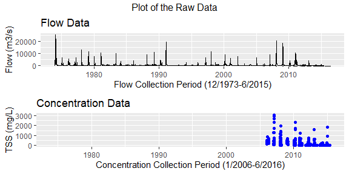

```r
# Version 2: burdRC and burdRQ are already stored as part of the package
burd <- ReadInDataFromR(x.C = burdRC, x.Q = burdRQ)
plot(burd)
```

```r
summary(burd)
```

```
## Flow Data:
## ---------
## Flow Collection Period: From  1973-12-02  to  2015-06-30
## No. of records:  15186   Average sampling frequency:  1 days
## Flow:     min=0 max=25482.8
##   percentiles: 25th (10) 50th (22) 75th (74.17) 90th (451.99) 95th (1377.12) 97.5th (2906.43) 99th (6488.2)
##   median=21.51
##   mean=302.26
##
## Concentration Data:
## -------------------
## Pollutant:  TSS
## Concentration Collection Period: From  2006-01-26  to  2016-06-23
## No. of records:  461   Average sampling frequency:  713927 secs
## Concentration:    min=1 max=3060
##   percentiles: 25th (28) 50th (135) 75th (313) 90th (451.99) 95th (812) 97.5th (1545) 99th (2304)
##   median=135
##   mean=264.49
```

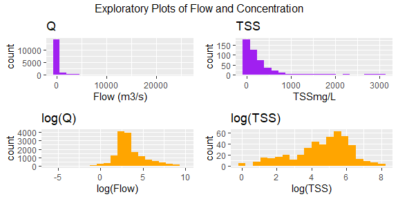

```r
ghist(burd)
```

### Step 2: Regularization

Before fitting the Generalized Additive Model or GAM we need to create a ‘regularised’ dataset, whereby a dataset of flow is created for a regular time interval e.g. daily. In addition to flow, additional terms that mimic the hydrological relationships inherent in many flow systems are also created at the daily time step. The inputs to the *CreateData* function are

- the flow and concentration data frames produced from Step 1 above;
- the date range for modelling (date.rangeM) and prediction (date.rangeP) and whether the dates have an hour component;
- the sampling unit (hour or day);
- the year type for summaries (water year (WY) or financial year (FY));
- the percentile used to calculate a flush (e.g. 0.9);
- whether infilling or regularization is to be performed (none, smoothers (ss) or quantile random forests (qrforest))

Below is an example where regularization was not required as flow data was available at the daily time step.

```r
date.rangeM <- c("1973-12-02", "2015-06-30")
date.rangeP <- c("1973-12-02", "2015-06-30")
loaddata <- CreateData(Q = burd$Q, Conc = burd$Conc,
                       date.range = list(model = date.rangeM, pred = date.rangeP, hour = FALSE),
                       samp.unit = "day", Ytype = "WY", Qflush = 0.9,
                       Reg = list(type = "none", rainfall = NULL, date = NULL))
```

We can then produce some exploratory plots to investigate the hydrological processes within the system.

```r
regplots <- plot(loaddata, Type = "WY")
names(regplots) # terms we can plot
```

```
## [1] "p_RiseFallLimb" "p_DistSum"      "p_CQsum"        "p_SmoothParms"
```

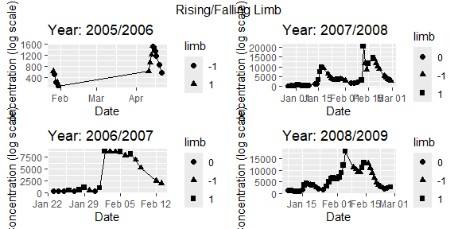

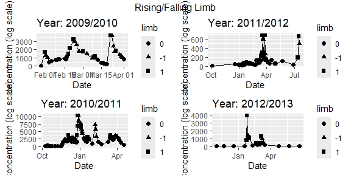

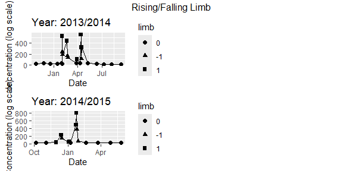

```r
# Rising Falling Limb
regplots$p_RiseFallLimb
```

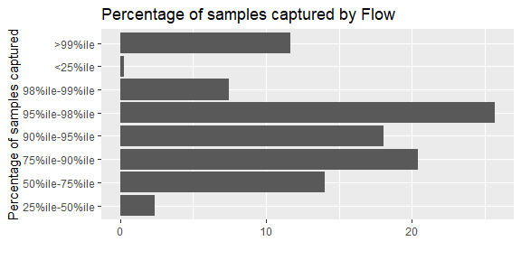

```r
# Distributional Summary
regplots$p_DistSum
```

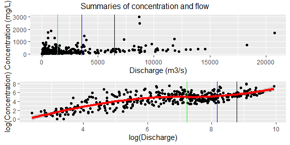

```r
# Flow and Concentration summary
regplots$p_CQsum
```

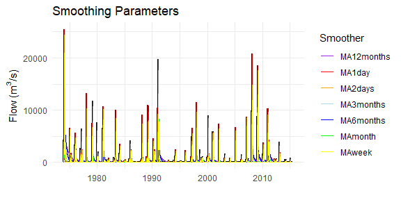

```r
# Smooth parameters
regplots$p_SmoothParms
```

Plots can also be saved using the *ggsave* function, which is part of the *ggplot2* package. Note, all plots are produced using the *ggplot2* package in R.

```r
# Save output as a pdf file
ggsave("p_SmoothParms.pdf", regplots$p_SmoothParms)
```

We can also produce some summaries of the regularized data. These summaries include a table outlining the bias in concentration and flow samples, broken up by water type (either water year (WY) or financial year (FY)) and a distributional summary of flow sampling to indicate the nature of the flow sampling undertaken.

```r
summary(loaddata)
```

```
## Bias in flow and concentration sampling:
##         Year  n  AvgFlowC   AvgFlowR   AvgFlowO FlowC.bias FlowQ.bias
## 1  1973/1974 NA        NA 2057.60410 2057.60410         NA          1
## 2  1974/1975 NA        NA  264.52109  264.52109         NA          1
## 3  1975/1976 NA        NA  374.91938  374.91938         NA          1
## 4  1976/1977 NA        NA  272.58740  272.58740         NA          1
## 5  1977/1978 NA        NA  165.90277  165.90277         NA          1
## 6  1978/1979 NA        NA  493.41670  493.41670         NA          1
## 7  1979/1980 NA        NA  145.24868  145.24868         NA          1
## 8  1980/1981 NA        NA  575.67087  575.67087         NA          1
## 9  1981/1982 NA        NA   67.75941   67.75941         NA          1
## 10 1982/1983 NA        NA  280.63198  280.63198         NA          1
## 11 1983/1984 NA        NA  170.57724  170.57724         NA          1
## 12 1984/1985 NA        NA   38.01298   38.01298         NA          1
## 13 1985/1986 NA        NA  119.32072  119.32072         NA          1
```

[output cut: 39 more lines]

### Step 3: Fit the GAM

A generalized additive model (GAM) can be fit to a log-transformed regularized dataset. The *FitModel* function fits a GAM using the mgcv package. While the *gam* function within *mgcv* can be used to fit the model directly, the *FitModel* function makes the implementation easier as the user just needs to specify what terms can be fit in the model (e.g. flow, seasonal, rising-falling limb (RFlimb), moving average (MA) terms, a trend term and autocorrelation through an AR1 process. Note, care should be taken when fitting trend terms in models, particularly their interpretation. The correlation term is fit using a generalized additive mixed model using the *gamm* function in the *mgcv* package and may take a considerable time to fit if *correlation = TRUE*.

**Tip 1:** When attempting to fit a GAM using the *FitModel* function, start with setting all parameters (apart from the trend and correlation arguments) to TRUE. Investigate the significance of the terms through the p-value and omit any terms, one by one, that are not significant starting with the terms that have the highest p-value. This approach is otherwise known as backward elimination. The model below is a result of a backward elimination process.

```r
mod1 <- FitModel(x = loaddata$CQ, parms = list(flow = "quadratic", seasonal = TRUE,
                                               RFlimb = FALSE,
                                               MA = c(MA1day = FALSE, MA2days = FALSE,
                                                      MAweek = TRUE,  MAmonth = TRUE,
                                                      MA6months = TRUE, MA12months = TRUE),
                                               trend = FALSE, correlation = FALSE))
```

```
## Fitting a Generalized Additive Model ...
```

```r
summary(mod1)
```

```
##
## Family: gaussian
## Link function: identity
##
## Formula:
## log(Conc) ~ LQflow(pQ, quad = TRUE) + s(month, bs = "cc") + NULL +
##     NULL + NULL + s(MAweek, bs = "cr") + s(MAmonth, bs = "cr") +
##     s(MA6months, bs = "cr") + s(MA12months, bs = "cr") + NULL
##
## Parametric coefficients:
##                          Estimate Std. Error t value Pr(>|t|)
## (Intercept)              10.54076    1.75035   6.022 4.53e-09 ***
## LQflow(pQ, quad = TRUE)1 -3.09315    0.54688  -5.656 3.32e-08 ***
## LQflow(pQ, quad = TRUE)2  0.30669    0.04213   7.280 2.40e-12 ***
## ---
## Signif. codes:  0 '***' 0.001 '**' 0.01 '*' 0.05 '.' 0.1 ' ' 1
##
## Approximate significance of smooth terms:
##                 edf Ref.df     F  p-value
## s(month)      5.462  8.000 1.911 0.008361 **
## s(MAweek)     9.000  9.000 7.453  < 2e-16 ***
## s(MAmonth)    6.771  7.207 2.063 0.046206 *
## s(MA6months)  8.942  8.995 3.367 0.000558 ***
## s(MA12months) 8.672  8.945 3.391 0.000622 ***
## ---
## Signif. codes:  0 '***' 0.001 '**' 0.01 '*' 0.05 '.' 0.1 ' ' 1
##
## R-sq.(adj) =  0.779   Deviance explained = 80.3%
## GCV = 0.62409  Scale est. = 0.55481   n = 377
```

```r
anova(mod1)
```

```
##
## Family: gaussian
## Link function: identity
##
## Formula:
## log(Conc) ~ LQflow(pQ, quad = TRUE) + s(month, bs = "cc") + NULL +
##     NULL + NULL + s(MAweek, bs = "cr") + s(MAmonth, bs = "cr") +
##     s(MA6months, bs = "cr") + s(MA12months, bs = "cr") + NULL
##
## Parametric Terms:
##                         df     F p-value
## LQflow(pQ, quad = TRUE)  2 44.35  <2e-16
##
## Approximate significance of smooth terms:
##                 edf Ref.df     F  p-value
## s(month)      5.462  8.000 1.911 0.008361
## s(MAweek)     9.000  9.000 7.453  < 2e-16
## s(MAmonth)    6.771  7.207 2.063 0.046206
## s(MA6months)  8.942  8.995 3.367 0.000558
## s(MA12months) 8.672  8.945 3.391 0.000622
```

```r
print(class(mod1))
```

```
## [1] "fitmodel" "gam"      "glm"      "lm"
```

### Step 4: Diagnostics

It is useful to check the fit and validity of your model through some diagnostic plots. The function *diagnostic* simplifies this process by producing two sets of figures. The first set (*pD*) produces 4 figures that allow the user to examine the fit of their model. The plots (from left to right) show a plot of

- the residuals versus fitted;
- histogram of residuals;
- a quantile-quantile or Q-Q plot of the residuals; and
- a plot of the predicted versus observed with a line of best fit.

The second figure examines the auto-correlation function of the residuals (*pacf*). In this figure we hope to see a dampening out of correlations over at past lags (i.e. spikes in correlations at lags where the spikes fall within the 95% confidence intervals). In the figure below we observe some correlation ~0.3 at a lag of 1 but this diminishes at lags 2 and beyond.

```r
mod1D <- diagnostic(mod1)
names(mod1D)
```

```
## [1] "pD"   "pacf"
```

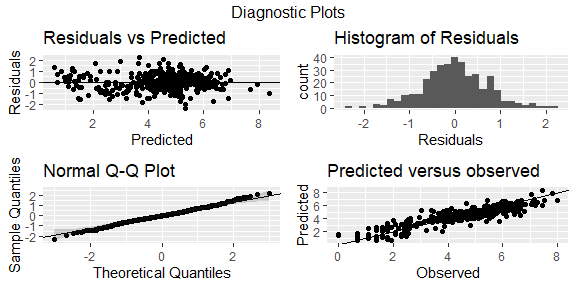

```r
# Diagnostic Plots
mod1D$pD
```

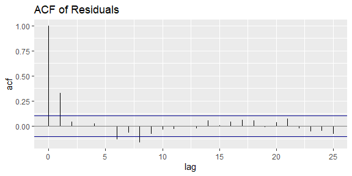

```r
# ACF of residuals
mod1D$pacf
```

### Step 5: Interpretation of the Model

It is important to gain an understanding of the terms fit in the model and how they relate to concentration. We can obtain a marginal representation of each term in the model by plotting the output from the fit of the model housed in the R object *mod1I*. As we only fit MA terms and a seasonal term, we can only plot these terms.

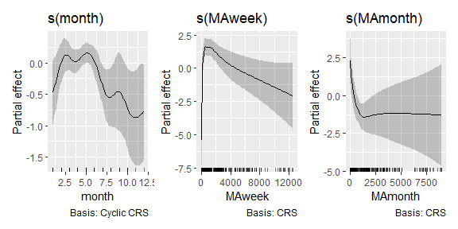

```r
library(gratia)    # exploring smoothers
library(patchwork) # package for arranging plots
p1 <- draw(mod1, select = "s(month)")
p2 <- draw(mod1, select = "s(MAweek)")
p3 <- draw(mod1, select = "s(MAmonth)")
p4 <- draw(mod1, select = "s(MA6months)")
p5 <- draw(mod1, select = "s(MA12months)")
p1 + p2 + p3 + plot_layout(ncol = 3)
```

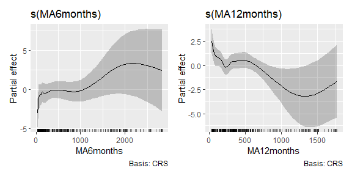

```r
p4 + p5 + plot_layout(ncol = 2)
```

We can also investigate the predicted concentration time series together with the regularized flow through the following plot.

```r
#Exploring predictions from model

mod1_expl <- plot(mod1, Qreg = loaddata$Qreg, data = loaddata$CQ)
names(mod1_expl)
```

```
## [1] "ppred"    "pConc"    "pConcInt"
```

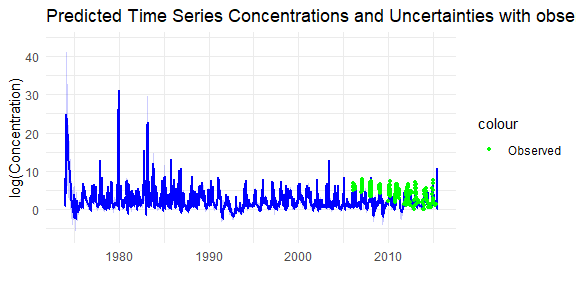

```r
mod1_expl$pConcInt
```

Sometimes it is also useful to plot the predicted concentrations interactively and explore the predictions at different parts of the time series by zooming in and zooming out using your mouse. Here is an example using the *ggplotly* function which is part of the *plotly* package in R. Note, the code below is not run for this vignette.

```r
# Investigate predicted concentration using ggplotly
#
library(plotly)
ggplotly(mod1I$pConc)
```

### Step 6: Predicting the Load with uncertainties

We can form estimates of the load with uncertainties using the *predictL* function in R. Using this function we can output two types of predictions. The first is the loads (*pL1*), while the second set of estimates are the flow weighted concentrations (*pFWC1*). Each of these estimates are accompanyied by confidence intervals, where the width of the confidence interval is determined by the pvalue argument that the user sets. By default, the error in flow is assumed to be zero but can be set through the flow.error argument. Users can enter a coefficient of variation that reflects the measurement error (*me*) and/or the spatial error or positioning of the flow gauge (*ce*). Load estimates can be produced at the annual scale (*type = annual*) or daily scale (*type = daily*).

```r
predLoad <- predictL(object = mod1, objfix = mod1$gam, x = loaddata, flow.error = list(me = 0, ce = 0),
                  samp.unit = "day", pvalue = 0.2)
```

```r
mod1pL <- plot(predLoad$loadest, type = "annual", Conc = "TSS", scale = "Mt")
names(mod1pL)
```

```
## [1] "pL1"   "pFWC1"
```

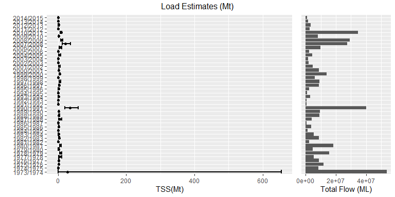

```r
# Annual loads
mod1pL$pL1
```

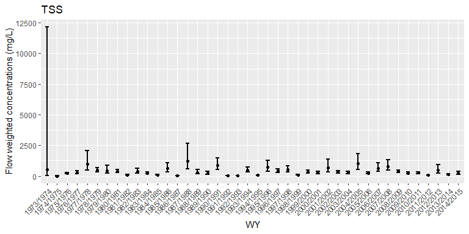

```r
# Flow weighted concentrations
mod1pL$pFWC1
```

An interactive plot of the flow weighted concentrations can be called using the *ggplotly* function. Note, this is not run for the vignette.

```r
# interactive flow weighted concentrations
ggplotly(mod1pL$pFWC1)
```

### Step 7: Storing Results

Load estimates can be accessed from the *predLoad* object as follows. These can then be written to file using the *write.csv* function in R.

```r
results <- predLoad$loadest
names(results)
```

```
## [1] "annual" "daily"
```

## Infilling Flow

When there are gaps in the flow record, we need a methodology for infilling flow to form a regularized dataset. In LRE, there are two approaches for achieving this. The first uses a smoothing spline approach using the *gam* function in the *mgcv* package. The second approach uses quantile Random Forests to fit a model between flow and rainfall at different lags to develop a predictive model that is used to predict flow at records with missing data.

To illustrate the two approaches, we artificially exclude 100 consecutive records spanning the date ranges: 2004-01-13 to 2004-04-22. This dataset is called *burdRNA*.

Below is an example of infilling using smoothing splines.

```r
date.rangeM <- c("2011-01-01", "2015-06-30")
date.rangeP <- c("2011-01-01", "2015-06-30")
loaddata <- CreateData(Q = burdRNA$Q, Conc = burdRNA$Conc,
                       date.range = list(model = date.rangeM, pred = date.rangeP, hour = FALSE),
                       samp.unit = "day", Ytype = "WY", Qflush = 0.9,
                       Reg = list(type = "ss"))
```

Here is an example of infilling using quantile Random Forests.

```r
date.rangeM <- c("2011-01-01", "2015-06-30")
date.rangeP <- c("2011-01-01", "2015-06-30")
loaddata <- CreateData(Q = burdRNA$Q, Conc = burdRNA$Conc,
                       date.range = list(model = date.rangeM, pred = date.rangeP, hour = FALSE),
                       samp.unit = "day", Ytype = "WY", Qflush = 0.9,
                       Reg = list(type = "qrforest", rainfall = burd_rain$Rainfall,
                                  date = burd_rain$Date))
```

## Reference

Kuhnert, P.M., Henderson, B.L., Lewis, S.E., Bainbridge, Z.T., Wilkinson, S.N. and Brodie, J.E. (2012) Quantifying total suspended sediment export from the Burdekin River catchment using the loads regression estimator tool, Water Resources Research, 48, W04533,doi:10.1029/2011WR011080.